# INTA 4803 Homework 2

Madi Wickett

```r
library(caret)
library(ROCR)
library(doMC)
library(tidyverse)
library(corrr)
library(e1071)
```

```r
training<-subset(fl_dataset, year <= 1980)
testing<-subset(fl_dataset, year > 1980)

training<-na.omit(training)
testing<-na.omit(testing)
```

```r
training$warstds<-factor(
  training$warstds,
  level = c(0, 1),
  labels = c("None", "CivilWar")
)

testing$warstds<-factor(
  testing$warstds,
  level = c(0, 1),
  labels = c("None", "CivilWar")
)
```

## Question I

### Fearon & Laitin (2003) Replication

```r
fitControl<-trainControl(method = "cv",
                         number = 10,
                         summaryFunction = twoClassSummary,
                         classProbs = TRUE,
                         savePredictions = TRUE)
```

```r
mod.logit<-train(as.factor(warstds) ~ ln_gdpen+lpopns+lmtnest+ncontig+oil+nwstate+inst3+pol4+ef+relfrac,
                 method = "glm",
                 trControl=fitControl,
                 family = "binomial",
                 metric = "ROC",
                 data = training[c(-1, -2)])
mod.logit
```

```
## Generalized Linear Model
##
## 3940 samples
##   10 predictor
##    2 classes: 'None', 'CivilWar'
##
## No pre-processing
## Resampling: Cross-Validated (10 fold)
## Summary of sample sizes: 3546, 3546, 3546, 3546, 3546, 3546, ...
## Resampling results:
##
##   ROC        Sens  Spec
##   0.7418471  1     0
```

As seen below, no onsets were correctly predicted by Fearon and Laitin’s model

```r
pred.mod.logit<-predict(mod.logit, newdata = testing, type = "raw")
confusionMatrix(pred.mod.logit, testing$warstds, positive = "CivilWar", mode = "everything")
```

```
## Confusion Matrix and Statistics
##
##           Reference
## Prediction None CivilWar
##   None     3153       47
##   CivilWar    0        0
##
##                Accuracy : 0.9853
##                  95% CI : (0.9805, 0.9892)
##     No Information Rate : 0.9853
##     P-Value [Acc > NIR] : 0.5387
##
##                   Kappa : 0
##
##  Mcnemar's Test P-Value : 1.949e-11
##
##             Sensitivity : 0.00000
##             Specificity : 1.00000
##          Pos Pred Value :     NaN
##          Neg Pred Value : 0.98531
##               Precision :      NA
##                  Recall : 0.00000
##                      F1 :      NA
##              Prevalence : 0.01469
##          Detection Rate : 0.00000
##    Detection Prevalence : 0.00000
##       Balanced Accuracy : 0.50000
##
##        'Positive' Class : CivilWar
##
```

### Elastic Net Model w/ F&L Features

An elastic net model using the same features as Fearon & Laitin’s study produces 0 correct onsets.

```r
set.seed(38745)
mod.enet<-train(as.factor(warstds) ~ warhist+ln_gdpen+lpopns+lmtnest+ncontig+oil+nwstate+inst3+pol4+ef+relfrac,
                 method = "glmnet",
                 trControl=fitControl,
                 metric = "ROC",
                 data = training[c(-1, -2)])
mod.enet
```

```
## glmnet
##
## 3940 samples
##   11 predictor
##    2 classes: 'None', 'CivilWar'
##
## No pre-processing
## Resampling: Cross-Validated (10 fold)
## Summary of sample sizes: 3546, 3546, 3546, 3547, 3546, 3546, ...
## Resampling results across tuning parameters:
##
##   alpha  lambda        ROC        Sens  Spec
##   0.10   2.566529e-05  0.7503702  1     0
##   0.10   2.566529e-04  0.7503702  1     0
##   0.10   2.566529e-03  0.7520253  1     0
##   0.55   2.566529e-05  0.7500505  1     0
##   0.55   2.566529e-04  0.7498474  1     0
##   0.55   2.566529e-03  0.7494564  1     0
##   1.00   2.566529e-05  0.7498166  1     0
##   1.00   2.566529e-04  0.7503884  1     0
##   1.00   2.566529e-03  0.7461270  1     0
##
## ROC was used to select the optimal model using the largest value.
## The final values used for the model were alpha = 0.1 and lambda = 0.002566529.
```

```r
pred.mod.enet<-predict(mod.enet, newdata = testing, type = "raw")
confusionMatrix(pred.mod.enet, testing$warstds, positive = "CivilWar", mode = "everything")
```

```
## Confusion Matrix and Statistics
##
##           Reference
## Prediction None CivilWar
##   None     3153       47
##   CivilWar    0        0
##
##                Accuracy : 0.9853
##                  95% CI : (0.9805, 0.9892)
##     No Information Rate : 0.9853
##     P-Value [Acc > NIR] : 0.5387
##
##                   Kappa : 0
##
##  Mcnemar's Test P-Value : 1.949e-11
##
##             Sensitivity : 0.00000
##             Specificity : 1.00000
##          Pos Pred Value :     NaN
##          Neg Pred Value : 0.98531
##               Precision :      NA
##                  Recall : 0.00000
##                      F1 :      NA
##              Prevalence : 0.01469
##          Detection Rate : 0.00000
##    Detection Prevalence : 0.00000
##       Balanced Accuracy : 0.50000
##
##        'Positive' Class : CivilWar
##
```

Non-zero factors for the Fearon and Laitin Model

```r
coef_fl<-coef(mod.enet$finalModel, mod.enet$bestTune$lambda)
as.table(as.matrix(coef_fl))
```

```
##                         1
## (Intercept) -8.1649034786
## warhist      0.1005524902
## ln_gdpen    -0.3486909955
## lpopns       0.1930874206
## lmtnest      0.1504734315
## ncontig     -0.0002598242
## oil          0.5434854802
## nwstate      1.5581104051
## inst3        1.2297247497
## pol4        -0.0055687639
## ef           0.1998205562
## relfrac      0.6019453750
```

### Elastic Net with All Features

An elastic net model with all features correctly predicts two civil war onsets.

```r
set.seed(38745)
mod.enet2<-train(as.factor(warstds) ~.,
                 method = "glmnet",
                 trControl=fitControl,
                 metric = "ROC",
                 data = training[c(-1, -2)])
mod.enet2
```

```
## glmnet
##
## 3940 samples
##   90 predictor
##    2 classes: 'None', 'CivilWar'
##
## No pre-processing
## Resampling: Cross-Validated (10 fold)
## Summary of sample sizes: 3546, 3546, 3546, 3547, 3546, 3546, ...
## Resampling results across tuning parameters:
##
##   alpha  lambda        ROC        Sens       Spec
##   0.10   2.566529e-05  0.8250547  0.9958676  0.10000000
##   0.10   2.566529e-04  0.8333068  0.9968999  0.07142857
##   0.10   2.566529e-03  0.8467432  0.9994832  0.00000000
##   0.55   2.566529e-05  0.8263904  0.9958676  0.10000000
##   0.55   2.566529e-04  0.8370133  0.9974167  0.07142857
##   0.55   2.566529e-03  0.8493812  1.0000000  0.00000000
##   1.00   2.566529e-05  0.8252782  0.9956099  0.10000000
##   1.00   2.566529e-04  0.8379240  0.9976751  0.04285714
##   1.00   2.566529e-03  0.8489355  1.0000000  0.00000000
##
## ROC was used to select the optimal model using the largest value.
## The final values used for the model were alpha = 0.55 and lambda = 0.002566529.
```

```r
pred.mod.enet2<-predict(mod.enet2, newdata = testing, type = "raw")
confusionMatrix(pred.mod.enet2, testing$warstds, positive = "CivilWar", mode = "everything")
```

```
## Confusion Matrix and Statistics
##
##           Reference
## Prediction None CivilWar
##   None     3151       45
##   CivilWar    2        2
##
##                Accuracy : 0.9853
##                  95% CI : (0.9805, 0.9892)
##     No Information Rate : 0.9853
##     P-Value [Acc > NIR] : 0.5387
##
##                   Kappa : 0.0763
##
##  Mcnemar's Test P-Value : 8.993e-10
##
##             Sensitivity : 0.042553
##             Specificity : 0.999366
##          Pos Pred Value : 0.500000
##          Neg Pred Value : 0.985920
##               Precision : 0.500000
##                  Recall : 0.042553
##                      F1 : 0.078431
##              Prevalence : 0.014687
##          Detection Rate : 0.000625
##    Detection Prevalence : 0.001250
##       Balanced Accuracy : 0.520959
##
##        'Positive' Class : CivilWar
##
```

Non-zero factors for all possible predictors

```r
coef_all<-coef(mod.enet2$finalModel, mod.enet2$bestTune$lambda)
coef_df<-as.data.frame(as.matrix(coef_all))
colnames(coef_df)<-c("value")
coef_nz<-subset(coef_df, value != 0)
as.table(as.matrix(coef_nz))
```

```
##                     value
## (Intercept) -3.8306137491
## autonomy    -0.0083787589
## centpol3     0.0004713508
## decade2     -0.1547610406
## decade3     -0.5202372171
## demch98      0.0943290676
## drel         0.0011014642
## elfo2        0.0001193801
## etdo4590     0.8092082832
## expgdp      -0.0183870369
## fuelexp      0.0015478205
## gdpgrowth   -6.8268654692
## geo2        -0.6034274673
## geo34        0.2678743892
## geo69        0.0086495633
## geo8        -0.1020923393
## illiteracy   0.0155668483
## incumb       0.7098884996
## inst3        0.8924023621
## lmtnest      0.1408117911
## ln_gdpen    -0.0249174356
## lpopns       0.0115565645
## major       -0.1681120932
## manuexp     -0.0044806141
## mirps0       0.7262678635
## mirps1      -0.1383317590
## nat_war      0.3643654586
## nwstate      1.3577796225
## oil          0.1576773182
## p4mchg      -0.0484538026
## parreg      -0.2475663105
## partfree     0.1019828174
## presi       -0.5898436987
## proxregc    -0.3389797382
## ptime       -0.0002428726
## relfrac      0.3314195187
## second      -1.0821828364
## semipol3    -0.6068236909
## sxpnew      -1.5182240200
## sxpsq       -1.8667147378
## trade       -0.0083625661
## xconst      -0.0228946063
```

### Explanation of results

The logistic regression model and the elastic net model with just Fearon and Laitin’s variables did not show any predictive power because they were overfit based on incorrect theory. While theory can be helpful for finding which correlations are spurious or which variables are just a translation of another variable, if the theory is incorrect, you may be excluding important predictors.

This is why the elastic net with all possible predictors performed the best out of the three. Without any bias from the researchers or the theory, we can see the influence of all possible variables

## Question II

```r
set.seed(38745)
train.rf<-train(as.factor(warstds)~.,
                method = "rf",
                trControl = fitControl,
                ntrees = 1000,
                metric = "ROC",
                sampsize=c(140, 50),
                data = training[c(-1, -2)]
                )
train.rf
```

```
## Random Forest
##
## 3940 samples
##   90 predictor
##    2 classes: 'None', 'CivilWar'
##
## No pre-processing
## Resampling: Cross-Validated (10 fold)
## Summary of sample sizes: 3546, 3546, 3546, 3547, 3546, 3546, ...
## Resampling results across tuning parameters:
##
##   mtry  ROC        Sens       Spec
##    2    0.9283000  0.9612496  0.4166667
##   46    0.9402448  0.9511794  0.6523810
##   90    0.9315591  0.9457551  0.6523810
##
## ROC was used to select the optimal model using the largest value.
## The final value used for the model was mtry = 46.
```

```r
pred.rf<-predict(train.rf, newdata = testing, type = "raw")
confusionMatrix(pred.rf, testing$warstds, positive = "CivilWar", mode = "everything")
```

```
## Confusion Matrix and Statistics
##
##           Reference
## Prediction None CivilWar
##   None     2968       23
##   CivilWar  185       24
##
##                Accuracy : 0.935
##                  95% CI : (0.9259, 0.9433)
##     No Information Rate : 0.9853
##     P-Value [Acc > NIR] : 1
##
##                   Kappa : 0.1675
##
##  Mcnemar's Test P-Value : <2e-16
##
##             Sensitivity : 0.51064
##             Specificity : 0.94133
##          Pos Pred Value : 0.11483
##          Neg Pred Value : 0.99231
##               Precision : 0.11483
##                  Recall : 0.51064
##                      F1 : 0.18750
##              Prevalence : 0.01469
##          Detection Rate : 0.00750
##    Detection Prevalence : 0.06531
##       Balanced Accuracy : 0.72598
##
##        'Positive' Class : CivilWar
##
```

Random forests correctly predicts 24 civil war onsets. It performs better than the elastic net because random forests randomly selects predictors, meaning that a single strong predictor won’t guide the entire model. Additionally, random forests internally cross-validates as it is training, so it’s out-of-bag predictions tend to be more accurate.

## Question III

### Predictive Accuracy

#### Precision

Elastic Net (F&L variables) - NA Elastic Net (All variables) - 0.500 Random Forests - 0.115

According to the precision measure, the Elastic Net with all variables makes the most accurate predictions. This measure is based on the number of true positives out of the number of predicted positives. The elastic net only predicted a few positives, but half of the ones predicted were true positives so it has relatively good precision. While random forests predicted more true positives, it also predicted many false positives.

#### Recall

Elastic Net (F&L) - 0.000 Elastic Net (All) - 0.043 Random Forests - 0.511

According to the recall measure, random forests has the most accurate predictions because it predicted over half of the total onsets.. This looks at the number of true positives out of the total positives. The reasoning is flipped from precision. For recall, we care more about the total number of true positives predicted rather than how many false positives were predicted.

#### F1 Statistic

Elastic Net (F&L) - NA Elastic Net (All) - 0.078 Random Forests - 0.187

According to the F1 statistic, random forests is the most accurate (though objectively not incredibly accurate). This is a combination of the previous two statistics that tries to balance precision and recall.

### ROC Plots

```r
pred.enet<-predict(mod.enet, newdata = testing, type = "prob")
enet.pred<-prediction(pred.enet$CivilWar, testing$warstds)
perf.enet<-performance(enet.pred, "tpr", "fpr")

pred.enet2<-predict(mod.enet2, newdata = testing, type = "prob")
enet2.pred<-prediction(pred.enet2$CivilWar, testing$warstds)
perf.enet2<-performance(enet2.pred, "tpr", "fpr")

predict.rf<-predict(train.rf, newdata = testing, type = "prob")
rf.pred<-prediction(predict.rf$CivilWar, testing$warstds)
perf.rf<-performance(rf.pred, "tpr", "fpr")
```

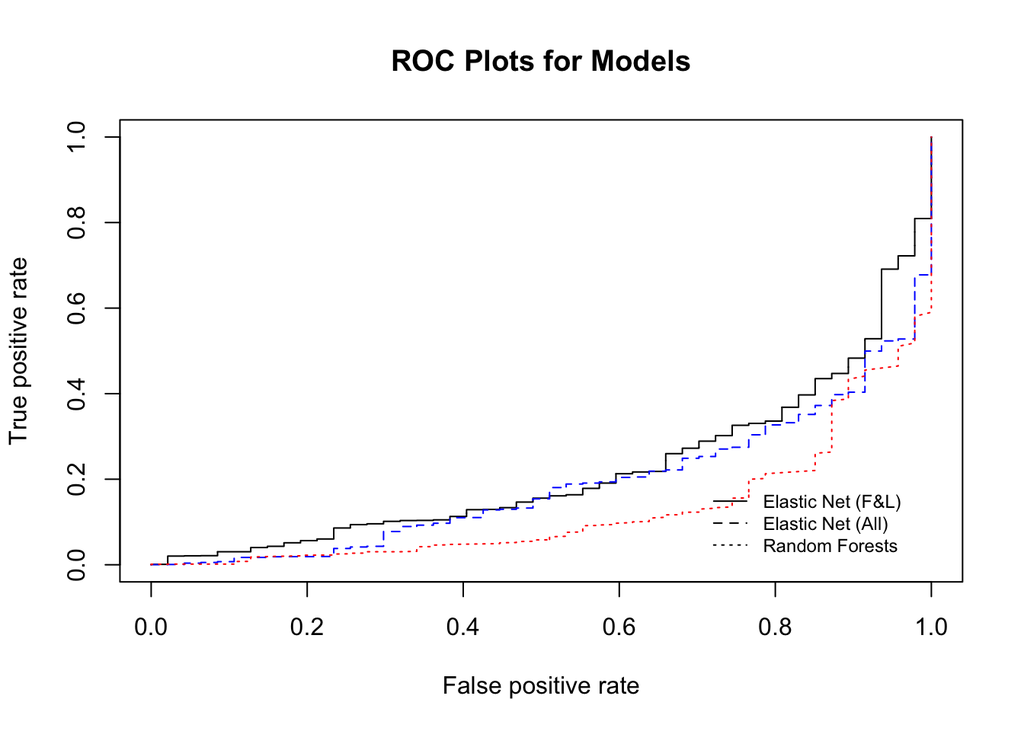

```r
plot(perf.enet, main="ROC Plots for Models")
plot(perf.enet2, add=T, lty=2, col="blue")
plot(perf.rf, add=T, lty=3, col="red")
legend(0.7, 0.2, c("Elastic Net (F&L)", "Elastic Net (All)", "Random Forests"), lty=c(1,2,3), bty="n", cex=0.75)
```

According to the ROC plots, the elastic net model with Fearon and Laitin’s variables is more accurate

### Area under Precision-Recall Curve

```r
pr.enet<-performance(enet.pred, "prec", "rec")
pr.enet2<-performance(enet2.pred, "prec", "rec")
pr.rf<-performance(rf.pred, "prec", "rec")
```

```r
as.numeric(performance(enet.pred, "aucpr")@y.values)
```

```
## [1] 0.9710677
```

```r
as.numeric(performance(enet2.pred, "aucpr")@y.values)
```

```
## [1] 0.9659323
```

```r
as.numeric(performance(rf.pred, "aucpr")@y.values)
```

```
## [1] 0.9597818
```

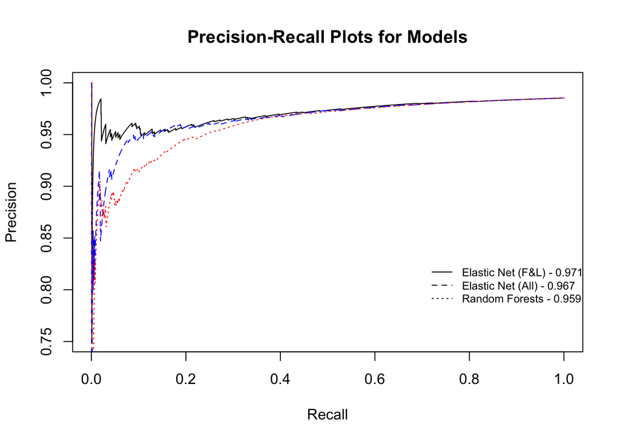

```r
plot(pr.enet, main="Precision-Recall Plots for Models")
plot(pr.enet2, add=T, lty=2, col="blue")
plot(pr.rf, add=T, lty=3, col="red")
legend(0.7, 0.83, c("Elastic Net (F&L) - 0.971", "Elastic Net (All) - 0.967", "Random Forests - 0.959"), lty=c(1,2,3), bty="n", cex=0.75)
```

According to the precision-recall plots, the elastic net model with Fearon and Laitin’s variables is more accurate.

### Conclusion

Model fit depends on the rarity of the event you are trying to predict as well as how you wish to use the model to make decisions. For events in international affairs, it’s clear that simple accuracy is not a sufficient measure, and policymakers want to decide whether a few, definite “yeses” are better than many realistic “maybes.”

## Question IV

### Gradient Boosted Trees

```r
set.seed(38745)
train.gbm<-train(as.factor(warstds)~.,
                 method = "gbm",
                 trControl = fitControl,
                 metric = "ROC",
                 data = training[c(-1, -2)])
train.gbm
```

```
## Stochastic Gradient Boosting
##
## 3940 samples
##   90 predictor
##    2 classes: 'None', 'CivilWar'
##
## No pre-processing
## Resampling: Cross-Validated (10 fold)
## Summary of sample sizes: 3546, 3546, 3546, 3547, 3546, 3546, ...
## Resampling results across tuning parameters:
##
##   interaction.depth  n.trees  ROC        Sens       Spec
##   1                   50      0.9282049  0.9997416  0.00000000
##   1                  100      0.9378211  0.9992248  0.04285714
##   1                  150      0.9442238  0.9987080  0.14523810
##   2                   50      0.9392708  0.9992248  0.21666667
##   2                  100      0.9432928  0.9989664  0.23095238
##   2                  150      0.9415643  0.9981919  0.23095238
##   3                   50      0.9393141  0.9974180  0.23095238
##   3                  100      0.9375460  0.9958683  0.25952381
##   3                  150      0.9380001  0.9963858  0.25952381
##
## Tuning parameter 'shrinkage' was held constant at a value of 0.1
##
## Tuning parameter 'n.minobsinnode' was held constant at a value of 10
## ROC was used to select the optimal model using the largest value.
## The final values used for the model were n.trees = 150, interaction.depth =
##  1, shrinkage = 0.1 and n.minobsinnode = 10.
```

```r
pred.gbm<-predict(train.gbm, newdata = testing, type = "raw")
confusionMatrix(pred.gbm, testing$warstds, positive = "CivilWar", mode = "everything")
```

```
## Confusion Matrix and Statistics
##
##           Reference
## Prediction None CivilWar
##   None     3141       43
##   CivilWar   12        4
##
##                Accuracy : 0.9828
##                  95% CI : (0.9777, 0.987)
##     No Information Rate : 0.9853
##     P-Value [Acc > NIR] : 0.8921
##
##                   Kappa : 0.1204
##
##  Mcnemar's Test P-Value : 5.228e-05
##
##             Sensitivity : 0.08511
##             Specificity : 0.99619
##          Pos Pred Value : 0.25000
##          Neg Pred Value : 0.98649
##               Precision : 0.25000
##                  Recall : 0.08511
##                      F1 : 0.12698
##              Prevalence : 0.01469
##          Detection Rate : 0.00125
##    Detection Prevalence : 0.00500
##       Balanced Accuracy : 0.54065
##
##        'Positive' Class : CivilWar
##
```

### Ensemble Modeling

```r
library(caretEnsemble)
algList<-c("glmnet", "rf", "gbm")

set.seed(38745)
models<-caretList(warstds~.,
                  data=training,
                  trControl = fitControl,
                  methodList = algList)
results<-resamples(models)
summary(results)
```

```
##
## Call:
## summary.resamples(object = results)
##
## Models: glmnet, rf, gbm
## Number of resamples: 10
##
## ROC
##             Min.   1st Qu.    Median      Mean   3rd Qu.      Max. NA's
## glmnet 0.7083795 0.7929125 0.8554817 0.8352212 0.8921189 0.9128830    0
## rf     0.8143226 0.9292174 0.9500738 0.9343521 0.9677246 0.9817276    0
## gbm    0.8623108 0.9276947 0.9641934 0.9452328 0.9682540 0.9727541    0
##
## Sens
##             Min.  1st Qu.    Median      Mean 3rd Qu. Max. NA's
## glmnet 0.9974227 1.000000 1.0000000 0.9997423       1    1    0
## rf     0.9974160 1.000000 1.0000000 0.9997416       1    1    0
## gbm    0.9948320 0.997416 0.9987113 0.9984503       1    1    0
##
## Spec
##        Min. 1st Qu.    Median       Mean   3rd Qu.      Max. NA's
## glmnet    0       0 0.0000000 0.00000000 0.0000000 0.0000000    0
## rf        0       0 0.0000000 0.01428571 0.0000000 0.1428571    0
## gbm       0       0 0.1428571 0.12857143 0.1428571 0.4285714    0
```

```r
stackControl<-trainControl(method="cv",
                           number = 10,
                           summaryFunction = twoClassSummary,
                           classProbs = T,
                           savePredictions = TRUE,
                           allowParallel = TRUE)

set.seed(38745)
stack.keras<-caretStack(models, method = "monmlp", metric="ROC", trControl = stackControl)
```

[output not shown]

[output cut: 68 more lines]

[output not shown]

```r
pred.stack_nn<-predict(stack.keras, newdata = testing, type = "raw")
```

```r
confusionMatrix(pred.stack_nn, testing$warstds, positive = "CivilWar", mode = "everything")
```

```
## Confusion Matrix and Statistics
##
##           Reference
## Prediction None CivilWar
##   None     3142       44
##   CivilWar   11        3
##
##                Accuracy : 0.9828
##                  95% CI : (0.9777, 0.987)
##     No Information Rate : 0.9853
##     P-Value [Acc > NIR] : 0.8921
##
##                   Kappa : 0.0922
##
##  Mcnemar's Test P-Value : 1.597e-05
##
##             Sensitivity : 0.0638298
##             Specificity : 0.9965113
##          Pos Pred Value : 0.2142857
##          Neg Pred Value : 0.9861896
##               Precision : 0.2142857
##                  Recall : 0.0638298
##                      F1 : 0.0983607
##              Prevalence : 0.0146875
##          Detection Rate : 0.0009375
##    Detection Prevalence : 0.0043750
##       Balanced Accuracy : 0.5301705
##
##        'Positive' Class : CivilWar
##
```